# Logistic Map

R. G. Cronce

10/2/2020

## Logistic Map

Aka the predator/prey equation - one of the simplest chaotic systems that occurs in virtually all of the articles about chaos. Representatitve of a system with competing birth/death rate (r) and a population (x). The iteration is:

```
x[n+1] = r*x[n]*(1-x[n])
```

Where:

```
x[n] = population at time n, in the range 0<x<1
x[n+1] = population at time n+1
r    = reproduction rate
```

When r is small the population dies out. When r has a medium value `(1<r<3)` there is a single steady state. For r>3 there is a bifurcation in the population level in subsequent generations. As r increases the bifurcations exhibit period doubling and eventual chaos. For small regions the response returns to simple bifurcation and then chaos resumes above that level of r. In order to see the chaotic behaviour you need to explore the same value of r for several iterations before moving on to the next value of r.

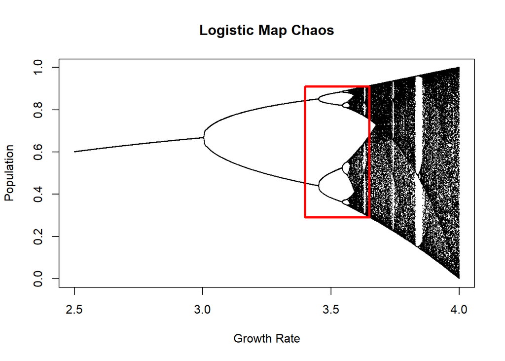

```r
logistic = function(x,r) {
    x=r*x*(1-x)
}

# Range of r values for exploration
r0=2.5
r1=4.0
# Number of repeats at each value of r
nrepeat=200

# Random starting point
z=runif(1)
# Iterate to get to a stationary point (if it exists) or on the attractor
for (i in 1:nrepeat) { z=logistic(z,r0) }
# Range of r values
r=seq(r0,r1,length=1000)
# Use nrepeat points at each value of r
x=rep(r,each=nrepeat)
y=0*x
for (i in seq_along(x)) {
    z=logistic(z,x[i])
    y[i]=z
}
plot(x,y,pch=19,cex=0.1,xlab="Growth Rate",ylab="Population",main="Logistic Map Chaos")
polygon(c(3.4,3.65,3.65,3.4),c(0.29,0.29,0.91,0.91),border="red",lwd=3)
```

This is the typical logistic map bifurcation diagram.

## Self-similarity

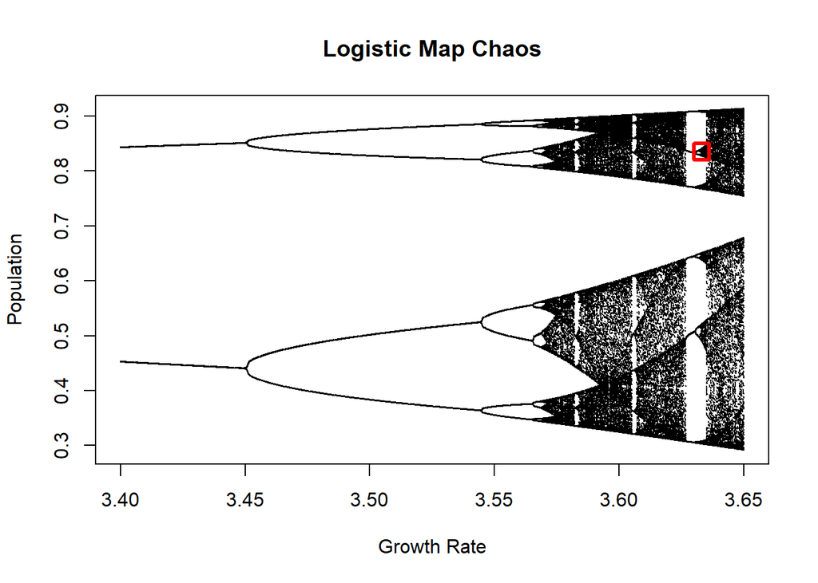

```r
# Range of r values for exploration
r0=3.4
r1=3.65
# Number of repeats at each value of r
nrepeat=200

# Random starting point
z=runif(1)
# Iterate to get to a stationary point (if it exists) or on the attractor
for (i in 1:nrepeat) { z=logistic(z,r0) }
# Range of r values
r=seq(r0,r1,length=1000)
# Use nrepeat points at each value of r
x=rep(r,each=nrepeat)
y=0*x
for (i in seq_along(x)) {
    z=logistic(z,x[i])
    y[i]=z
}
plot(x,y,pch=19,cex=0.1,xlab="Growth Rate",ylab="Population",main="Logistic Map Chaos")
polygon(c(3.63,3.636,3.636,3.63),c(0.82,0.82,0.85,0.85),border="red",lwd=3)
```

## Stability within Chaos

The small area boxed in red above is examined below. Note the self-similarity to the previous plots and the abrupt transition from chaos to/from well-ordered behavior.

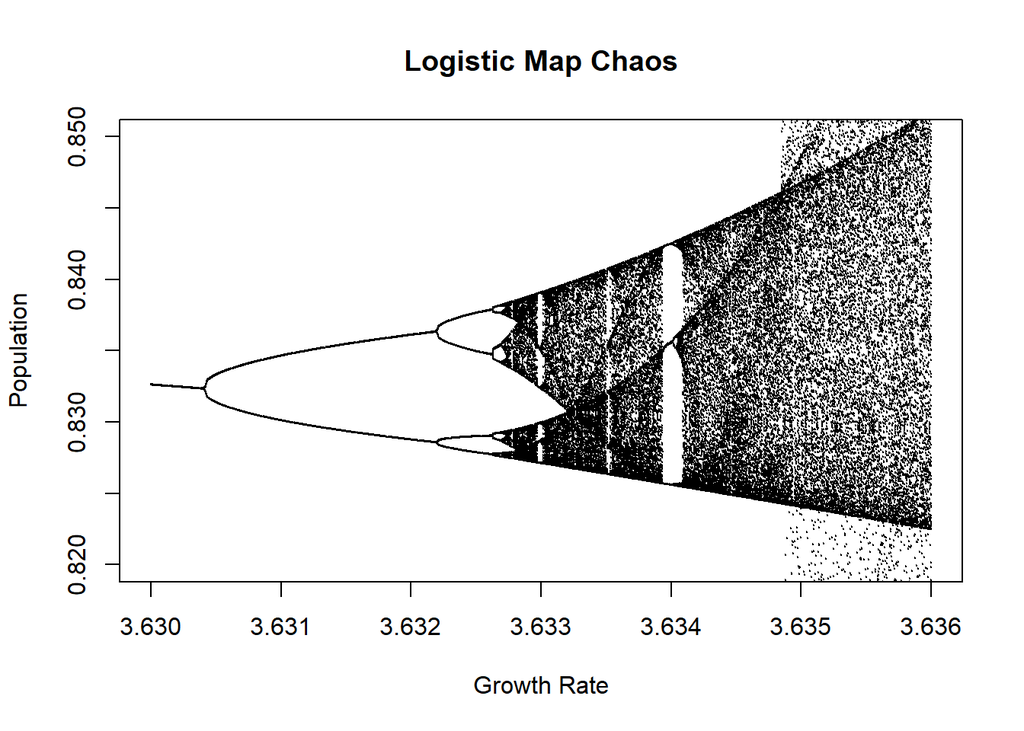

```r
# Range of r values for exploration
r0=3.63
r1=3.636
# Number of repeats at each value of r
nrepeat=600

# Random starting point
z=runif(1)
# Iterate to get to a stationary point (if it exists) or on the attractor
for (i in 1:nrepeat) { z=logistic(z,r0) }
# Range of r values
r=seq(r0,r1,length=1000)
# Use nrepeat points at each value of r
x=rep(r,each=nrepeat)
y=0*x
for (i in seq_along(x)) {
    z=logistic(z,x[i])
    y[i]=z
}
plot(x,y,pch=19,cex=0.1,
     ylim=c(0.82,0.85),
     xlab="Growth Rate",ylab="Population",main="Logistic Map Chaos")
```